# rAssignment10

Tobias Borzyk

2026-01-19

# r Assignment 10 Analyse Time Series

Please write an Rmd file with html output, which computes the trend of the air temperature recorded in Cölbe based on monthly values between January 1950 and December 1990 (we stop here because afterwards, there is a gap in the time series, which could be filled in principle but not as part of this task) Please extend your Rmd file in such a manner that you can evaluate to which degree the dynamics in the seasonal temperature over each year can be explained by fluctuations of the North Atlantic Oscillation. For this task, divide the NAO index provided above into “positive” and “negative” (i.e. use it as a factor, not as a numeric variable) and predict the temperature dynamics in a simple multiple linear model, which uses the NAO index classes as a factor and the first Fourier frequency (i.e. one sin and one cos) as independent variables. Finally, develop a strategy to cross-check the significance indicated by the linear model.

```r
library("rdwd")  #dt. Wetterdienst-library implementieren

## Daten herunterladen und einlesen
setwd("C:/Users/borzy/Documents/GEOmaster/Data_Analysis")
data_path <- ("C:/Users/borzy/Documents/GEOmaster/Data_Analysis/data/")
url <- rdwd::selectDWD(id = "03164", res = "monthly", var = "kl", per = "historical")
rdwd::dataDWD(url, dir = data_path, read = FALSE)
```

[output not shown]

[output not shown]

```r
# adapt path to where your file actually is and filename to the downloaded time span, Daten einlesen, manuell entzippen
path <- ("C:/Users/borzy/Documents/GEOmaster/Data_Analysis/data/monthly_kl_historical_monatswerte_KL_03164_18810101_20241231_hist/produkt_klima_monat_18810101_20241231_03164.txt")
dwd <- read.table(path, header = TRUE, sep = ";", dec = ".")
# check
head(dwd)
```

```
##   STATIONS_ID MESS_DATUM_BEGINN MESS_DATUM_ENDE QN_4 MO_N MO_TT MO_TX MO_TN
## 1        3164          18810101        18810131    5 -999  -5.9  -3.0  -9.5
## 2        3164          18810201        18810228    5 -999   0.9   4.0  -2.2
## 3        3164          18810301        18810331    5 -999   3.6   7.5   0.0
## 4        3164          18810401        18810430    5 -999   6.0  10.6   1.1
## 5        3164          18810501        18810531    5 -999  12.1  17.3   6.2
## 6        3164          18810601        18810630    5 -999  15.3  20.4   9.7
##   MO_FK MX_TX MX_FX MX_TN MO_SD_S QN_6 MO_RR MX_RS eor
## 1  -999  -999  -999  -999    -999    5    32  -999 eor
## 2  -999  -999  -999  -999    -999    5    41  -999 eor
## 3  -999  -999  -999  -999    -999    5    83  -999 eor
## 4  -999  -999  -999  -999    -999    5    16  -999 eor
## 5  -999  -999  -999  -999    -999    5    48  -999 eor
## 6  -999  -999  -999  -999    -999    5    37  -999 eor
```

```r
nao <- read.table(file.path(data_path,
  "nao_indextim.sec.txt"),
  header = TRUE,
  skip = 8,
  sep = "",
  na.strings = "-99.90",
  stringsAsFactors = FALSE
)
head(nao)
```

```
##   YEAR MONTH INDEX
## 1 1950     1  0.56
## 2 1950     2  0.01
## 3 1950     3 -0.78
## 4 1950     4  0.65
## 5 1950     5 -0.50
## 6 1950     6  0.25
```

```r
#Fehlwerte lösche
dwd <- dwd[dwd$MO_TT != -999, ]
dwd <- dwd[dwd$MO_TX != -999, ]
dwd <- dwd[dwd$MO_TN != -999, ]

#Extrahieren relevanter Spalten
dwd <- dwd[, c(2,6,7,8)]

#Umbenennung in kürzere Namen
colnames(dwd) <- c("Monat", "T_Mittel", "T_Max", "T_Min")

dwd$Monat <- as.Date(as.character(dwd$Monat), format = "%Y%m%d")

#Zeitraum zwischen 1950 und 1990 bringen
dwd <- dwd[dwd$Monat >= "1950-01-01" &
           dwd$Monat <= "1990-12-01", ]
# Libraries für Visualisierung und Co
library(tidyr)
library(dplyr)
```

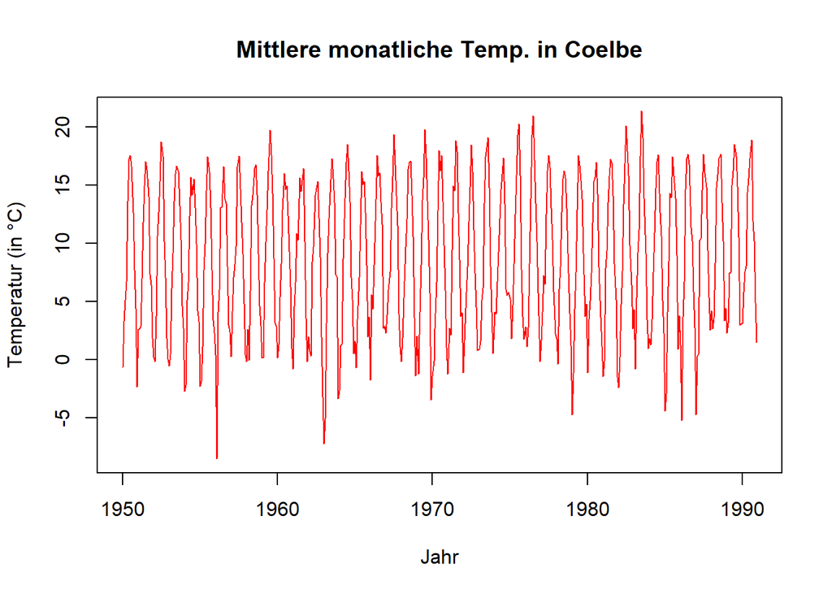

```r
library(ggplot2)

# Womit haben wir es zu tun? Plot der mittleren monatlichen Temperatur in Cölbe
plot(dwd$Monat, dwd$T_Mittel, type = "l", xlab="Jahr", ylab="Temperatur (in °C)", main="Mittlere monatliche Temp. in Coelbe", col="red")
```

### Trend Berechnung für 1950-1990

```r
# Hilfsvariablen
dwd <- dwd %>%
  arrange(Monat) %>%
  mutate(
    t = seq_len(n()),                       # Zeitindex (Monate)
    m = as.integer(format(Monat, "%m")),    # Monat (1..12)
    sindwd = sin(2*pi*m/12),                  # 1. Fourier-Frequenz
    cosdwd = cos(2*pi*m/12)
  )

# Trendmodell: Temperatur ~ Trend + Saison (sin/cos)
m_trend <- lm(T_Mittel ~ t + sindwd + cosdwd, data = dwd)
summary(m_trend)
```

```
##
## Call:
## lm(formula = T_Mittel ~ t + sindwd + cosdwd, data = dwd)
##
## Residuals:
##     Min      1Q  Median      3Q     Max
## -9.1311 -1.0134  0.0653  1.0699  5.0903
##
## Coefficients:
##               Estimate Std. Error t value Pr(>|t|)
## (Intercept)  8.1644383  0.1622349   50.33  < 2e-16 ***
## t            0.0022856  0.0005715    4.00 7.33e-05 ***
## sindwd      -4.6652769  0.1144898  -40.75  < 2e-16 ***
## cosdwd      -7.3643860  0.1145891  -64.27  < 2e-16 ***
## ---
## Signif. codes:  0 '***' 0.001 '**' 0.01 '*' 0.05 '.' 0.1 ' ' 1
##
## Residual standard error: 1.794 on 487 degrees of freedom
## Multiple R-squared:  0.9228, Adjusted R-squared:  0.9223
## F-statistic:  1940 on 3 and 487 DF,  p-value: < 2.2e-16
```

```r
# Trend in °C pro Jahr und pro Dekade
beta_month <- coef(m_trend)["t"]
trend_year  <- beta_month * 12
trend_dec   <- beta_month * 120

trend_year
```

```
##          t
## 0.02742694
```

```r
trend_dec
```

```
##         t
## 0.2742694
```

```r
library(dplyr)
library(tidyr)


nao2 <- nao %>%
  transmute(
    Year = as.integer(YEAR),
    month_num = as.integer(MONTH),
    NAO = as.numeric(INDEX),
    Date = as.Date(sprintf("%04d-%02d-01", Year, month_num)),
    Sign = factor(ifelse(NAO < 0, "negative", "positive"),
                  levels = c("negative", "positive"))
  ) %>%
  filter(Date >= as.Date("1950-01-01"),
         Date <= as.Date("1990-12-01")) %>%
  select(Date, NAO, Sign)

# Join mit DWD über Datum (ohne doppelt sin und cos)
dat <- dwd %>%
  rename(Date = Monat) %>%
  left_join(nao2 %>% select(Date, NAO, Sign), by = "Date") %>%
  mutate(
    m = as.integer(format(Date, "%m")),
    sin1 = sin(2*pi*m/12),
    cos1 = cos(2*pi*m/12)
  )

# Kontrolle: sollten 0 NAs sein
sum(is.na(dat$Sign))
```

```
## [1] 0
```

```r
head(dat)
```

```
##         Date T_Mittel T_Max T_Min t m       sindwd        cosdwd   NAO     Sign
## 1 1950-01-01    -0.65  2.15 -4.07 1 1 5.000000e-01  8.660254e-01  0.56 positive
## 2 1950-02-01     3.28  6.44  0.15 2 2 8.660254e-01  5.000000e-01  0.01 positive
## 3 1950-03-01     5.10 10.02  0.43 3 3 1.000000e+00  6.123032e-17 -0.78 negative
## 4 1950-04-01     6.72 11.21  2.67 4 4 8.660254e-01 -5.000000e-01  0.65 positive
## 5 1950-05-01    13.62 19.89  7.77 5 5 5.000000e-01 -8.660254e-01 -0.50 negative
## 6 1950-06-01    17.23 23.91 11.05 6 6 1.224606e-16 -1.000000e+00  0.25 positive
##           sin1          cos1
## 1 5.000000e-01  8.660254e-01
## 2 8.660254e-01  5.000000e-01
## 3 1.000000e+00  6.123032e-17
## 4 8.660254e-01 -5.000000e-01
## 5 5.000000e-01 -8.660254e-01
## 6 1.224606e-16 -1.000000e+00
```

```r
m0 <- lm(T_Mittel ~ sin1 + cos1, data = dat)                 # nur Saison
m1 <- lm(T_Mittel ~ Sign + sin1 + cos1, data = dat)          # Saison + NAO-Klasse

anova(m0, m1)   # Zusatznutzen von NAO-Klasse
```

```
## Analysis of Variance Table
##
## Model 1: T_Mittel ~ sin1 + cos1
## Model 2: T_Mittel ~ Sign + sin1 + cos1
##   Res.Df    RSS Df Sum of Sq      F    Pr(>F)
## 1    488 1619.8
## 2    487 1515.9  1    103.89 33.377 1.356e-08 ***
## ---
## Signif. codes:  0 '***' 0.001 '**' 0.01 '*' 0.05 '.' 0.1 ' ' 1
```

```r
summary(m1)
```

```
##
## Call:
## lm(formula = T_Mittel ~ Sign + sin1 + cos1, data = dat)
##
## Residuals:
##     Min      1Q  Median      3Q     Max
## -9.1720 -1.0232 -0.0537  1.1402  4.9180
##
## Coefficients:
##              Estimate Std. Error t value Pr(>|t|)
## (Intercept)    8.2767     0.1114  74.310  < 2e-16 ***
## Signpositive   0.9322     0.1614   5.777 1.36e-08 ***
## sin1          -4.5823     0.1136 -40.322  < 2e-16 ***
## cos1          -7.3126     0.1130 -64.720  < 2e-16 ***
## ---
## Signif. codes:  0 '***' 0.001 '**' 0.01 '*' 0.05 '.' 0.1 ' ' 1
##
## Residual standard error: 1.764 on 487 degrees of freedom
## Multiple R-squared:  0.9254, Adjusted R-squared:  0.9249
## F-statistic:  2013 on 3 and 487 DF,  p-value: < 2.2e-16
```

```r
dat$month <- as.integer(format(dat$Date, "%m"))
# Permutationstest
m_obs <- lm(T_Mittel ~ Sign + sin1 + cos1, data=dat)
t_obs <- summary(m_obs)$coefficients["Signpositive","t value"]

B <- 2000
t_perm <- numeric(B)

set.seed(1)
for(b in 1:B){
  perm <- dat
  perm$Sign <- unlist(tapply(perm$Sign, perm$month, sample))  # permutiere innerhalb Monat
  m_b <- lm(T_Mittel ~ Sign + sin1 + cos1, data=perm)
  t_perm[b] <- summary(m_b)$coefficients["Signpositive","t value"]
}

p_perm <- mean(abs(t_perm) >= abs(t_obs))
p_perm
```

```
## [1] 0
```

```r
adj0 <- summary(m0)$adj.r.squared
adj1 <- summary(m1)$adj.r.squared
delta_adj_r2 <- adj1 - adj0
delta_adj_r2
```

```
## [1] 0.004982002
```